# B88_Groves_Search_One_Qubit_Reprsentation

| Abuzer Yakaryilmaz \| May 1, 2019 (updated) |
| --- |
| This cell contains some macros. If there is a problem with displaying mathematical formulas, please run this cell to load these macros. |

$ \newcommand{\bra}[1]{\langle #1|} $ $ \newcommand{\ket}[1]{|#1\rangle} $ $ \newcommand{\braket}[2]{\langle #1|#2\rangle} $ $ \newcommand{\dot}[2]{ #1 \cdot #2} $ $ \newcommand{\biginner}[2]{\left\langle #1,#2\right\rangle} $ $ \newcommand{\mymatrix}[2]{\left( \begin{array}{#1} #2\end{array} \right)} $ $ \newcommand{\myvector}[1]{\mymatrix{c}{#1}} $ $ \newcommand{\myrvector}[1]{\mymatrix{r}{#1}} $ $ \newcommand{\mypar}[1]{\left( #1 \right)} $ $ \newcommand{\mybigpar}[1]{ \Big( #1 \Big)} $ $ \newcommand{\sqrttwo}{\frac{1}{\sqrt{2}}} $ $ \newcommand{\dsqrttwo}{\dfrac{1}{\sqrt{2}}} $ $ \newcommand{\onehalf}{\frac{1}{2}} $ $ \newcommand{\donehalf}{\dfrac{1}{2}} $ $ \newcommand{\hadamard}{ \mymatrix{rr}{ \sqrttwo & \sqrttwo \\ \sqrttwo & -\sqrttwo }} $ $ \newcommand{\vzero}{\myvector{1\\0}} $ $ \newcommand{\vone}{\myvector{0\\1}} $ $ \newcommand{\vhadamardzero}{\myvector{ \sqrttwo \\ \sqrttwo } } $ $ \newcommand{\vhadamardone}{ \myrvector{ \sqrttwo \\ -\sqrttwo } } $ $ \newcommand{\myarray}[2]{ \begin{array}{#1}#2\end{array}} $ $ \newcommand{\X}{ \mymatrix{cc}{0 & 1 \\ 1 & 0} } $ $ \newcommand{\Z}{ \mymatrix{rr}{1 & 0 \\ 0 & -1} } $ $ \newcommand{\Htwo}{ \mymatrix{rrrr}{ \frac{1}{2} & \frac{1}{2} & \frac{1}{2} & \frac{1}{2} \\ \frac{1}{2} & -\frac{1}{2} & \frac{1}{2} & -\frac{1}{2} \\ \frac{1}{2} & \frac{1}{2} & -\frac{1}{2} & -\frac{1}{2} \\ \frac{1}{2} & -\frac{1}{2} & -\frac{1}{2} & \frac{1}{2} } } $ $ \newcommand{\CNOT}{ \mymatrix{cccc}{1 & 0 & 0 & 0 \\ 0 & 1 & 0 & 0 \\ 0 & 0 & 0 & 1 \\ 0 & 0 & 1 & 0} } $ $ \newcommand{\norm}[1]{ \left\lVert #1 \right\rVert } $

## Grover's Search: One Qubit Representation

Grover's search algorithm is one of the well-known quantum algorithms.

It finds a marked element in an unsorted list quadratically better than the classical algorithms.

Grover's search algorithm iteratively applies two reflections (in query and inversion phases).

Here, we visually trace the operations in each iteration of Grover's search algorithm on the unit circle.

### Representation of data

Suppose that we have 16 elements in our list.

The list has marked and unmarked elements. (A marked element refers to a searching item.)

Each quantum state will be associated with a different index of the list.

Four qubits have 16 different states ($ \ket{0000}, \ldots, \ket{1111} $), and so we use 4 qubits.

We assume that when we keep the whole list "quantumly", we can check whether an item is marked or not in a single step by using its index.

For example, if the element associated with the state $ \ket{1101} $ is marked, then we can detect this by changing the sign of this state.

We remind that conditionally changing the sign of a quantum state is one of the basic operations.

*In general, if we have a list of size $ 2^k $, then we can use $ k $ qubits and associate each state with one of the items in the list.*

### Search in parallel

We can access each element in the list with one of the basis states.

We start in state $ \ket{0000} $.

Then, we apply Hadamard to each qubit.

Remember that $ \ket{0000} = \ket{0} \otimes \ket{0} \otimes \ket{0} \otimes \ket{0} $, or equivalently $ \ket{0000} = \ket{0}\ket{0}\ket{0}\ket{0} $ by omitting tensor symbol.

After Hadamard operator, our quantum state is

$ \ket{u} = H\ket{0} \otimes H\ket{0} \otimes H\ket{0} \otimes H\ket{0} $, which is

$$ \ket{u} = \mypar{ \frac{1}{\sqrt{2}} \ket{0} + \frac{1}{\sqrt{2}} \ket{1} } \otimes \mypar{ \frac{1}{\sqrt{2}} \ket{0} + \frac{1}{\sqrt{2}} \ket{1} } \otimes \mypar{ \frac{1}{\sqrt{2}} \ket{0} + \frac{1}{\sqrt{2}} \ket{1} } \otimes \mypar{ \frac{1}{\sqrt{2}} \ket{0} + \frac{1}{\sqrt{2}} \ket{1} }. $$

From this tensor product, we can get every basis state of 4 qubits having the amplitude $ \frac{1}{4} $:

$$ \ket{u}= \frac{1}{4} \ket{0000} + \frac{1}{4} \ket{0001} + \frac{1}{4} \ket{0010} + \frac{1}{4} \ket{0011} + \cdots \cdots + \frac{1}{4} \ket{1101} + \frac{1}{4} \ket{1110} + \frac{1}{4} \ket{1111}. $$

Thus, after Hadamard, we can access each index in parallel, because we are in a superposition of all basis states, or in a superposition of all indices of the list.

However, the probability of observing any basis state at this moment is exponentially small: $ \frac{1}{16} $.

(It is $ \frac{1}{2^k} $ if there are $ 2^k $ elements.)

### Task 1

Design a quantum circuit with 4 qubits.

Apply Hadamard to each qubit and perform a measurement.

Execute your circuit 1600 times.

You should observe each basis state around 100 times.

Reexecute your circuit 16000 times.

```python
# import all necessary objects and methods for quantum circuits
from qiskit import QuantumRegister, ClassicalRegister, QuantumCircuit, execute, Aer
#
# your solution is here
#
from qiskit import QuantumRegister, ClassicalRegister, QuantumCircuit, execute, Aer

# Quantum Circuit with 4 qbits
qreg = QuantumRegister(4) # quantum register with 4 qubits
creg = ClassicalRegister(4) # classical register with 4 bits
mycircuit = QuantumCircuit(qreg,creg) # quantum circuit with quantum and classical registers

# Apply Hadamard to each one of the q-bits
for i in range(4):
    mycircuit.h(qreg[i])

# perform measurement
mycircuit.measure(qreg,creg)

# Execute circuit 16000 times
job = execute(mycircuit,Aer.get_backend('qasm_simulator'),shots=1600)
counts = job.result().get_counts(mycircuit)
# reverse q-bits to have a readable format
for outcome in counts:
    reverse_outcome = ''
    for i in outcome:
        reverse_outcome = i + reverse_outcome
    print(reverse_outcome,"is observed",counts[outcome],"times")
```

```
1100 is observed 84 times
0110 is observed 119 times
0000 is observed 121 times
0100 is observed 104 times
0001 is observed 96 times
0101 is observed 103 times
1110 is observed 85 times
1111 is observed 105 times
0011 is observed 92 times
1101 is observed 90 times
1000 is observed 110 times
0010 is observed 96 times
1011 is observed 99 times
1001 is observed 103 times
1010 is observed 101 times
0111 is observed 92 times
```

click for our solution

### Unit circle representation

For representing a quantum state $ \ket{u} $, we need 16-dimensional space.

But, we can map $\ket{u} $ to 2-dimensional space.

We have marked elements and unmarked elements.

We can group the states associated with marked elements and the states associated with unmarked elements.

Then, we can represent $ \ket{u} $ as a summation of two quantum states $ \ket{u} = a \ket{u_{marked}} + b \ket{u_{unmarked}} $.

The states in $ \ket{u_{marked}} $ and $ \ket{u_{unmarked}} $ do not have any common nonzero basis states.

Therefore, they are orthogonal to each other.

We can represent $ \ket{u} = a \ket{u_{marked}} + b \ket{u_{unmarked}} $ in 2-dimension as below:

[figure not shown]

Remark that if all elements are marked, then $ \ket{u} = \ket{u_{marked}} $, and if all elements are unmarked, then $ \ket{u} = \ket{u_{unmarked}}$.

For example, if we have 3 marked elements in our example, then we can find our parameters as follows.

Let the marked states be $ \ket{marked1} , \ket{marked2} , \ket{marked3} $.

Let the unmarked states be $ \ket{unmarked1} , \ket{unmarked2} , \ldots, \ket{unmarked13} $.

In $ \ket{u} $, each of this states has the amplitude $ \frac{1}{\sqrt{16}} $:

$$ \ket{u} = \frac{1}{\sqrt{16}} \mypar{ \ket{marked1} + \ket{marked2} + \ket{marked3} } + \frac{1}{\sqrt{16}} \mypar{ \ket{unmarked1} + \ket{unmarked2} + \cdots + \ket{unmarked13} } $$

### Task 2

If $ \frac{1}{\sqrt{16}} \mypar{ \ket{marked1} + \ket{marked2} + \ket{marked3} } = a \ket{u_{marked}} $, then

- find the value of $a$
- and $ \ket{u_{marked}} $,

where $ u_{marked} $ should be a quantum state (unit vector).

If $ \frac{1}{\sqrt{16}} \mypar{ \ket{unmarked1} + \ket{unmarked2} + \cdots + \ket{unmarked13} } = b \ket{u_{unmarked}} $, then

- find the value of $b$
- and $ \ket{u_{unmarked}} $,

where $ u_{unmarked} $ should be a quantum state (unit vector).

### Solution:

(from answer)

We start with $ \ket{marked1} + \ket{marked2} + \ket{marked3} $. The length of this vector is $ \sqrt{1^2+1^2+1^2} = \sqrt{3} $.

Therefore, this vector can have length 1 after normalizing by factor $ \frac{1}{\sqrt{3}} $.

Thus,

$$ \frac{1}{\sqrt{16}} \mypar{ \ket{marked1} + \ket{marked2} + \ket{marked3} } = \frac{1}{\sqrt{16}} \frac{\sqrt{3}}{\sqrt{3}} \mypar{ \ket{marked1} + \ket{marked2} + \ket{marked3} }, $$

which is equivalent to $$ = \frac{\sqrt{3}}{\sqrt{16}} \mypar{ \dfrac{ \ket{marked1} + \ket{marked2} + \ket{marked3} } {\sqrt{3}} }. $$

Thus, $ a = \sqrt{\dfrac{3}{16}} $ and $ \ket{u_{marked}} = \mypar{ \dfrac{ \ket{marked1} + \ket{marked2} + \ket{marked3} } {\sqrt{3}} } $.

We continue with $ \ket{unmarked1} + \ket{unmarked2} + \cdots + \ket{unmarked13} $. The length of this vector is $ \sqrt{\underbrace{1^2+\cdots+1^2}_{13~times}} = \sqrt{13} $.

Therefore, this vector can have length 1 after normalizing by factor $ \frac{1}{\sqrt{13}} $.

Thus,

$$ \frac{1}{\sqrt{16}} \mypar{ \ket{unmarked1} + \ket{unmarked2} + \cdots + \ket{unmarked13} } = \frac{1}{\sqrt{16}} \frac{\sqrt{13}}{\sqrt{13}} \mypar{ \ket{unmarked1} + \ket{unmarked2} + \cdots + \ket{unmarked13} }, $$

which is equivalent to $$ = \frac{\sqrt{13}}{\sqrt{16}} \mypar{ \dfrac{ \ket{unmarked1} + \ket{unmarked2} + \cdots + \ket{unmarked13} } {\sqrt{13}} }. $$

The idea here is to select $ \ket{u_{marked}} $ and $\ket{u_{unmarked}} $ as quantum states, i.e., their lengths should be 1.

In this way, we can also keep the ratio of $ \frac{3}{13} $ as ratio of

- the probability of observing a state in $ \ket{u_{marked}} $ and
- the probability of observing a state in $ \ket{u_{unmarked}} $.

Remark that the first probability is $ a^2 = \frac{3}{16} $ and the second probability is $ b^2 = \frac{13}{16} $.

click for our solution

### The idea behind Grover's search

The idea behind Grover's search algorithm is that

- the amplitudes of the marked (less frequent) elements can be quickly amplified,
- and so the probability of observing one of the marked elements quickly approches to 1.

For "quick" amplification, we iteratively apply two reflections to our quantum states.

The first reflection is a clockwise rotation, and the second rotation is counterclockwise.

The second rotation always rotates twice of the first rotation.

Therefore, our quantum state rotates in counterclockwise direction after two reflections.

As an analogy, we consider the rotation on the unit circle with angle $ \frac{\pi}{8} $ that starts in $ \ket{0} $.

- After every 4 rotations, we visit in order $ \ket{1} $, $ -\ket{0} $, $ -\ket{1} $, again $ \ket{0} $, and so on.
- Remark that the probability of observing the state $ \ket{1} $ oscillates between 0 and 1 while rotating.

Similarly, when iterating Grover's search algorithm, we should be careful when to stop.

- Because, after hitting a maximum value, these amplitudes start to quickly decrease, and after hitting a minimum value, they are amplified again, and so on.

### One iteration of the algorithm

Once we have the unit circle representation, then we can describe the algorithm very easily.

Grover's search algorithm simply implements two reflections, which can be implement as two rotations.

The axis of the first reflection is the quantum state $ \ket{u_{unmarked}} $.

The axis of the second reflection is the first quantum state after Hadamard operators: $ \ket{u} $.

During all iterations, these axes are fixed.

Remark that both of them depend on only the list and marked/unmarked elements.

[figure not shown]

**Grover's search algorithm:**

Start in $ \ket{u} $.

Iteratively:

1. Reflection over the first axis: Flip the sign of the states associated with the marked elements.
2. Reflection over the second axis: Then, reflect the resulting quantum state over the $\ket{u}$-axis.

After the first reflection: the current quantum state rotates with angle $ -2 \theta $.

[figure not shown]

After the second reflection: the reflected state rotates with angle $ 4 \theta $.

[figure not shown]

Then, the angle of the new quantum state is $ 3 \theta $.

The second iteration:

- The angle of the new quantum state is $ 3 \theta $.
- After the first reflection (rotation by $ -6 \theta $): The reflected quantum state has angle $ -3 \theta $.
- The angle between the reflected quantum state and the second reflection axis is $ 4 \theta $.
- With the second reflection, the reflected quantum state rotates $ 8 \theta $.
- Thus, the angle of the newest state will be $ 5\theta $.

**Hence, after each iteration the angle of the quantum state will be increased by $ 2 \theta $.**

In this way, the quantum state iteratively approaches to $ \ket{u_{marked}} $.

If we do not stop the iterations, then it passes $ \ket{u_{marked}} $, and starts to approach $ - \ket{u_{unmarked}} $.

If the quantum state is sufficiently close to $ \ket{u_{marked}} $ and we make a measurement, we can observe a marked element with high probability.

This is also the place to stop the iterations.

### Task 3

Set the value of $ k $ to 4. Then, the size of list is $ 2^k = 16 $.

Pick the value of $ m $ as 3, the number of the marked elements.

*In general, if we have $ 2^k $ elements and $ m $ of them are marked, then $ a = \frac{\sqrt{m}}{\sqrt{2^k}} $ and $ b= \frac{\sqrt{2^k - m}}{\sqrt{2^k}} $.*

$ \ket{u} = \sqrt{\frac{3}{16}} \ket{u_{marked}} + \sqrt{\frac{13}{16}} \ket{u_{unmarked}} $.

Create a quantum circuit with single qubit.

States $ \ket{1} $ and $ \ket{0} $ represent the quantum states $ \ket{u_{marked}} $ and $ \ket{u_{unmarked}}$, respectively.

Then, $ \ket{u} = \sqrt{\frac{13}{16}} \ket{0} + \sqrt{\frac{3}{16}} \ket{1} $.

**Determine the angle $ \theta $, the angle between $ \ket{u} $ and $ \ket{0} $.**

**Iterate Grover's search algorithm once by using your quantum circuit.**

For each reflection, use ry-gate (rotation).

- Define a list to store all quantum states (with their labels) that will be visited.
- Implement the first reflection on your qubit.
- Read the current quantum state and store it on your list.
- Implement the second reflection on your qubit.
- Read the current quantum state and store it on your list.
- Draw all visited quantum states with their labels.
- Execute your circuit 100 times.

Is this single iteration enough to observe state $ \ket{1} $ more than state $ \ket{0} $?

```
{'1': 92, '0': 8}
```

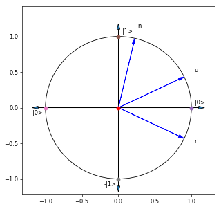

```python
# include our predefined functions
%run qlatvia.py

# import all necessary objects and methods for quantum circuits
from qiskit import QuantumRegister, ClassicalRegister, QuantumCircuit, execute, Aer
from math import acos, pi
# after Hadamard operators
u = [(13/16)**0.5,(3/16)**0.5]

def angle_between_two_states(u1,u2):
    dot_product = u1[0]*u2[0]+u1[1]*u2[1]
    return acos(dot_product)

theta = angle_between_two_states(u,[1,0])

all_visited_quantum_states =[]


qreg2 = QuantumRegister(1) # quantum register with 1 qubit
creg2 = ClassicalRegister(1) # classical register with 1 bit
mycircuit2 = QuantumCircuit(qreg2,creg2) # quantum circuit with quantum and classical registers


# set the qubit to |u> by rotating it by theta
mycircuit2.ry(2*theta,qreg2[0])

# read and store the current quantum state
current_state = execute(mycircuit2,Aer.get_backend('statevector_simulator')).result().get_statevector(mycircuit2)
[x,y] = [current_state[0].real,current_state[1].real]
all_visited_quantum_states.append([x,y,'u'])


# the first reflection
theta = angle_between_two_states([x,y],[1,0])
mycircuit2.ry(2*(-2*theta),qreg2[0])

# read and store the current quantum state
current_state = execute(mycircuit2,Aer.get_backend('statevector_simulator')).result().get_statevector(mycircuit2)
[x,y] = [current_state[0].real,current_state[1].real]
all_visited_quantum_states.append([x,y,'r'])



# the second reflection
theta = angle_between_two_states(u,[x,y])
mycircuit2.ry(2*(2*theta),qreg2[0])

# read and store the current quantum state
current_state = execute(mycircuit2,Aer.get_backend('statevector_simulator')).result().get_statevector(mycircuit2)
[x,y] = [current_state[0].real,current_state[1].real]
all_visited_quantum_states.append([x,y,'n'])

# measure the qubit
mycircuit2.measure(qreg2,creg2)


# execute the circuit 100 times, and print the outcomes
job = execute(mycircuit2,Aer.get_backend('qasm_simulator'),shots=100)
counts2 = job.result().get_counts(mycircuit2)
print(counts2)

# visualization
draw_qubit()
for quantum_state in all_visited_quantum_states:
    draw_quantum_state(quantum_state[0],quantum_state[1],quantum_state[2])
```

click for our solution

### Task 4

Set the value of $ k $ to 6. Then, the size of list is $ 2^k = 64 $.

Pick the value of $ m $ as 1, the number of the marked elements.

As described above, $ \ket{u} = \sqrt{\frac{1}{64}} \ket{u_{marked}} + \sqrt{\frac{63}{64}} \ket{u_{unmarked}} $.

Create a quantum circuit with single qubit.

States $ \ket{1} $ and $ \ket{0} $ represent the quantum states $ \ket{u_{marked}} $ and $ \ket{u_{unmarked}}$, respectively.

Then, $ \ket{u} = \sqrt{\frac{63}{64}} \ket{0} + \sqrt{\frac{1}{64}} \ket{1} $.

**Determine the angle $ \theta $, the angle between $ \ket{u} $ and $ \ket{0} $.**

**Iterate Grover's search algorithm three times by using your quantum circuit.**

For each reflection, use ry-gate (rotation).

- Define a list to store all quantum states (with their labels) that will be visited.
- Iterate 3 times:
  - Implement the first reflection on your qubit.
  - Read the current quantum state and store it on your list.
  - Implement the second reflection on your qubit.
  - Read the current quantum state and store it on your list.
- Draw all visited quantum states with their labels.
- Execute your circuit 100 times.

Is 3 iterations enough to observe state $ \ket{1} $ more than state $ \ket{0} $?

Try 4, 5, 6, 7, 8, 9, and 10 iterations.

What is the best number of iterations?

```
{'1': 62, '0': 38}
```

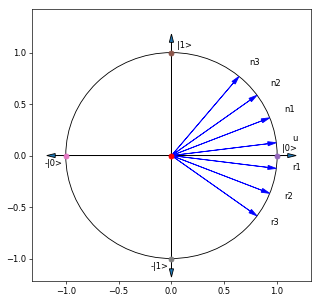

```python
# include our predefined functions
%run qlatvia.py

# import all necessary objects and methods for quantum circuits
from qiskit import QuantumRegister, ClassicalRegister, QuantumCircuit, execute, Aer
from math import acos, pi
# after Hadamard operators
u = [(63/64)**0.5,(1/64)**0.5]

def angle_between_two_states(u1,u2):
    dot_product = u1[0]*u2[0]+u1[1]*u2[1]
    return acos(dot_product)

theta = angle_between_two_states(u,[1,0])

all_visited_quantum_states =[]


qreg3 = QuantumRegister(1) # quantum register with 1 qubit
creg3 = ClassicalRegister(1) # classical register with 1 bit
mycircuit3 = QuantumCircuit(qreg3,creg3) # quantum circuit with quantum and classical registers


# set the qubit to |u> by rotating it by theta
mycircuit3.ry(2*theta,qreg3[0])

# read and store the current quantum state
current_state = execute(mycircuit3,Aer.get_backend('statevector_simulator')).result().get_statevector(mycircuit3)
[x,y] = [current_state[0].real,current_state[1].real]
all_visited_quantum_states.append([x,y,'u'])


# three iterations
for i in range(3): # 4,5,6,7,8,9,10
    # the first reflection
    theta = angle_between_two_states([x,y],[1,0])
    mycircuit3.ry(2*(-2*theta),qreg3[0])

    # read and store the current quantum state
    current_state = execute(mycircuit3,Aer.get_backend('statevector_simulator')).result().get_statevector(mycircuit3)
    [x,y] = [current_state[0].real,current_state[1].real]
    all_visited_quantum_states.append([x,y,'r'+str(i+1)])

    # the second reflection
    theta = angle_between_two_states(u,[x,y])
    mycircuit3.ry(2*(2*theta),qreg3[0])

    # read and store the current quantum state
    current_state = execute(mycircuit3,Aer.get_backend('statevector_simulator')).result().get_statevector(mycircuit3)
    [x,y] = [current_state[0].real,current_state[1].real]
    all_visited_quantum_states.append([x,y,'n'+str(i+1)])

# measure the qubit
mycircuit3.measure(qreg3,creg3)


# execute the circuit 100 times, and print the outcomes
job = execute(mycircuit3,Aer.get_backend('qasm_simulator'),shots=100)
counts3 = job.result().get_counts(mycircuit3)
print(counts3)

# visualization
draw_qubit()
for quantum_state in all_visited_quantum_states:
    draw_quantum_state(quantum_state[0],quantum_state[1],quantum_state[2])
```

click for our solution

### Task 5

Repeat Task 4 for $ k = 4 $ and $ m = 12 $.

However, iterate the algorithm for 1, 2, 3, and then 4 times, and visualize only $ \ket{u} $ and the states from the last iteration.

click for our solution

### The number of iterations

If there is a single marked element in a list of size $ N $, then $ \pi \dfrac{\sqrt{N}}{4} $ iterations can give the marked element with high probability.

If there are $k$ marked elements, then it is better to iterate $ \pi \dfrac{\sqrt{\frac{N}{k}}}{4} $ times.

If $k$ is unknown, then we can execute the algorithm with different iterations. One way of doing this is to iterate the algorithm

$$ \pi \dfrac{\sqrt{\frac{N}{1}}}{4}, \pi \dfrac{\sqrt{\frac{N}{2}}}{4}, \pi \dfrac{\sqrt{\frac{N}{4}}}{4}, \pi \dfrac{\sqrt{\frac{N}{8}}}{4}, \ldots $$

times.

The total number of iterations will still be proportional to $ \pi \dfrac{\sqrt{N}}{4} $: $ O \Big( \pi \dfrac{\sqrt{N}}{4} \Big) $.

[output not shown]

[figure not shown]

```python
# include our predefined functions
%run qlatvia.py

# import all necessary objects and methods for quantum circuits
from qiskit import QuantumRegister, ClassicalRegister, QuantumCircuit, execute, Aer
from math import acos, pi
# after Hadamard operators
u = [(4/16)**0.5,(12/16)**0.5]

def angle_between_two_states(u1,u2):
    dot_product = u1[0]*u2[0]+u1[1]*u2[1]
    return acos(dot_product)

theta = angle_between_two_states(u,[1,0])

all_visited_quantum_states = []


qreg3 = QuantumRegister(1) # quantum register with 1 qubit
creg3 = ClassicalRegister(1) # classical register with 1 bit
mycircuit3 = QuantumCircuit(qreg3,creg3) # quantum circuit with quantum and classical registers


# set the qubit to |u> by rotating it by theta
mycircuit3.ry(2*theta,qreg3[0])

# read and store the current quantum state
current_state = execute(mycircuit3,Aer.get_backend('statevector_simulator')).result().get_statevector(mycircuit3)
[x,y] = [current_state[0].real,current_state[1].real]
all_visited_quantum_states.append([x,y,'u'])


# three iterations
number_of_iterations = 1 # 2, 3, and 4
for i in range(number_of_iterations):
    # the first reflection
    theta = angle_between_two_states([x,y],[1,0])
    mycircuit3.ry(2*(-2*theta),qreg3[0])

    # read and store the current quantum state
    current_state = execute(mycircuit3,Aer.get_backend('statevector_simulator')).result().get_statevector(mycircuit3)
    [x,y] = [current_state[0].real,current_state[1].real]
    if i == number_of_iterations -1: all_visited_quantum_states.append([x,y,'r'+str(i+1)])

    # the second reflection
    theta = angle_between_two_states(u,[x,y])
    mycircuit3.ry(2*(2*theta),qreg3[0])

    # read and store the current quantum state
    current_state = execute(mycircuit3,Aer.get_backend('statevector_simulator')).result().get_statevector(mycircuit3)
    [x,y] = [current_state[0].real,current_state[1].real]
    if i == number_of_iterations -1: all_visited_quantum_states.append([x,y,'n'+str(i+1)])

# measure the qubit
mycircuit3.measure(qreg3,creg3)


# execute the circuit 100 times, and print the outcomes
job = execute(mycircuit3,Aer.get_backend('qasm_simulator'),shots=100)
counts3 = job.result().get_counts(mycircuit3)
print(counts3)

# visualization
draw_qubit()
for quantum_state in all_visited_quantum_states:
    draw_quantum_state(quantum_state[0],quantum_state[1],quantum_state[2])
```